# HW4 - IE582

EmreGokce - Mehmet Purazer - Yunus Koloğlu

05 12 2019

In order to work with bigger data, I used data from 2004 to 2019. There 5560 Premier League matches in total.

```r
library('RODBC')
myConn <- odbcConnect("IE582_HW1")

#The data loaded from https://www.football-data.co.uk/englandm.php . I used the data from 2004. The files includes match scores and average odd ratios for each premier league match

PL_2019 <- read.csv('C:/Users/emreg/Desktop/Master/IE582/Project/ProjectData/PLData/2019.csv', ,sep = ",")
PL_2018 <- read.csv('C:/Users/emreg/Desktop/Master/IE582/Project/ProjectData/PLData/2018.csv', ,sep = ",")
PL_2017 <- read.csv('C:/Users/emreg/Desktop/Master/IE582/Project/ProjectData/PLData/2017.csv', ,sep = ",")
PL_2016 <- read.csv('C:/Users/emreg/Desktop/Master/IE582/Project/ProjectData/PLData/2016.csv', ,sep = ",")
PL_2015 <- read.csv('C:/Users/emreg/Desktop/Master/IE582/Project/ProjectData/PLData/2015.csv', ,sep = ",")
PL_2014 <- read.csv('C:/Users/emreg/Desktop/Master/IE582/Project/ProjectData/PLData/2014.csv', ,sep = ",")
PL_2013 <- read.csv('C:/Users/emreg/Desktop/Master/IE582/Project/ProjectData/PLData/2013.csv', ,sep = ",")
PL_2012 <- read.csv('C:/Users/emreg/Desktop/Master/IE582/Project/ProjectData/PLData/2012.csv', ,sep = ",")
PL_2011 <- read.csv('C:/Users/emreg/Desktop/Master/IE582/Project/ProjectData/PLData/2011.csv', ,sep = ",")
PL_2010 <- read.csv('C:/Users/emreg/Desktop/Master/IE582/Project/ProjectData/PLData/2010.csv', ,sep = ",")
PL_2009 <- read.csv('C:/Users/emreg/Desktop/Master/IE582/Project/ProjectData/PLData/2009.csv', ,sep = ",")
PL_2008 <- read.csv('C:/Users/emreg/Desktop/Master/IE582/Project/ProjectData/PLData/2008.csv', ,sep = ",")
PL_2007 <- read.csv('C:/Users/emreg/Desktop/Master/IE582/Project/ProjectData/PLData/2007.csv', ,sep = ",")
PL_2006 <- read.csv('C:/Users/emreg/Desktop/Master/IE582/Project/ProjectData/PLData/2006.csv', ,sep = ",")
PL_2005 <- read.csv('C:/Users/emreg/Desktop/Master/IE582/Project/ProjectData/PLData/2005.csv', ,sep = ",")
PL_2004 <- read.csv('C:/Users/emreg/Desktop/Master/IE582/Project/ProjectData/PLData/2004.csv', ,sep = ",")

sqlQuery(myConn,"IF EXISTS(SELECT *  FROM   PL_2019)  DROP TABLE PL_2019")
```

```
## character(0)
```

```r
sqlQuery(myConn,"IF EXISTS(SELECT *  FROM   PL_2018)  DROP TABLE PL_2018")
```

```
## character(0)
```

```r
sqlQuery(myConn,"IF EXISTS(SELECT *  FROM   PL_2017)  DROP TABLE PL_2017")
```

```
## character(0)
```

```r
sqlQuery(myConn,"IF EXISTS(SELECT *  FROM   PL_2016)  DROP TABLE PL_2016")
```

```
## character(0)
```

```r
sqlQuery(myConn,"IF EXISTS(SELECT *  FROM   PL_2015)  DROP TABLE PL_2015")
```

```
## character(0)
```

```r
sqlQuery(myConn,"IF EXISTS(SELECT *  FROM   PL_2014)  DROP TABLE PL_2014")
```

```
## character(0)
```

```r
sqlQuery(myConn,"IF EXISTS(SELECT *  FROM   PL_2013)  DROP TABLE PL_2013")
```

```
## character(0)
```

```r
sqlQuery(myConn,"IF EXISTS(SELECT *  FROM   PL_2012)  DROP TABLE PL_2012")
```

```
## character(0)
```

```r
sqlQuery(myConn,"IF EXISTS(SELECT *  FROM   PL_2011)  DROP TABLE PL_2011")
```

```
## character(0)
```

```r
sqlQuery(myConn,"IF EXISTS(SELECT *  FROM   PL_2010)  DROP TABLE PL_2010")
```

```
## character(0)
```

```r
sqlQuery(myConn,"IF EXISTS(SELECT *  FROM   PL_2009)  DROP TABLE PL_2009")
```

```
## character(0)
```

```r
sqlQuery(myConn,"IF EXISTS(SELECT *  FROM   PL_2008)  DROP TABLE PL_2008")
```

```
## character(0)
```

```r
sqlQuery(myConn,"IF EXISTS(SELECT *  FROM   PL_2007)  DROP TABLE PL_2007")
```

```
## character(0)
```

```r
sqlQuery(myConn,"IF EXISTS(SELECT *  FROM   PL_2006)  DROP TABLE PL_2006")
```

```
## character(0)
```

```r
sqlQuery(myConn,"IF EXISTS(SELECT *  FROM   PL_2005)  DROP TABLE PL_2005")
```

```
## character(0)
```

```r
sqlQuery(myConn,"IF EXISTS(SELECT *  FROM   PL_2004)  DROP TABLE PL_2004")
```

```
## character(0)
```

```r
sqlSave(myConn,PL_2019,tablename="PL_2019",rownames = F)
sqlSave(myConn,PL_2018,tablename="PL_2018",rownames = F)
sqlSave(myConn,PL_2017,tablename="PL_2017",rownames = F)
sqlSave(myConn,PL_2016,tablename="PL_2016",rownames = F)
sqlSave(myConn,PL_2015,tablename="PL_2015",rownames = F)
sqlSave(myConn,PL_2014,tablename="PL_2014",rownames = F)
sqlSave(myConn,PL_2013,tablename="PL_2013",rownames = F)
sqlSave(myConn,PL_2012,tablename="PL_2012",rownames = F)
sqlSave(myConn,PL_2011,tablename="PL_2011",rownames = F)
sqlSave(myConn,PL_2010,tablename="PL_2010",rownames = F)
sqlSave(myConn,PL_2009,tablename="PL_2009",rownames = F)
sqlSave(myConn,PL_2008,tablename="PL_2008",rownames = F)
sqlSave(myConn,PL_2007,tablename="PL_2007",rownames = F)
sqlSave(myConn,PL_2006,tablename="PL_2006",rownames = F)
sqlSave(myConn,PL_2005,tablename="PL_2005",rownames = F)
sqlSave(myConn,PL_2004,tablename="PL_2004",rownames = F)

#Here I am combining all files and assigning it to PL_AllData dataframe
PL_AllData <-
sqlQuery(myConn,"
SELECT [Date] ,[HomeTeam],[AwayTeam],[FTHG],[FTAG],[FTR],B365H,B365D,B365A,B36525,B365251 FROM [IE582_HW1].[dbo].[PL_2019]   UNION
SELECT [Date] ,[HomeTeam],[AwayTeam],[FTHG],[FTAG],[FTR],B365H,B365D,B365A,BbAv25,BBAv251 FROM [IE582_HW1].[dbo].[PL_2018]   UNION
SELECT [Date] ,[HomeTeam],[AwayTeam],[FTHG],[FTAG],[FTR],B365H,B365D,B365A,BbAv25,BBAv251 FROM [IE582_HW1].[dbo].[PL_2017]   UNION
SELECT [Date] ,[HomeTeam],[AwayTeam],[FTHG],[FTAG],[FTR],B365H,B365D,B365A,BbAv25,BBAv251 FROM [IE582_HW1].[dbo].[PL_2016]   UNION
SELECT [Date] ,[HomeTeam],[AwayTeam],[FTHG],[FTAG],[FTR],B365H,B365D,B365A,BbAv25,BBAv251 FROM [IE582_HW1].[dbo].[PL_2015]   UNION
SELECT [Date] ,[HomeTeam],[AwayTeam],[FTHG],[FTAG],[FTR],B365H,B365D,B365A,BbAv25,BBAv251 FROM [IE582_HW1].[dbo].[PL_2014]   UNION
SELECT [Date] ,[HomeTeam],[AwayTeam],[FTHG],[FTAG],[FTR],B365H,B365D,B365A,BbAv25,BBAv251 FROM [IE582_HW1].[dbo].[PL_2013]   UNION
SELECT [Date] ,[HomeTeam],[AwayTeam],[FTHG],[FTAG],[FTR],B365H,B365D,B365A,BbAv25,BBAv251 FROM [IE582_HW1].[dbo].[PL_2012]   UNION
SELECT [Date] ,[HomeTeam],[AwayTeam],[FTHG],[FTAG],[FTR],B365H,B365D,B365A,BbAv25,BBAv251 FROM [IE582_HW1].[dbo].[PL_2011]   UNION
SELECT [Date] ,[HomeTeam],[AwayTeam],[FTHG],[FTAG],[FTR],B365H,B365D,B365A,BbAv25,BBAv251 FROM [IE582_HW1].[dbo].[PL_2010]   UNION
SELECT [Date] ,[HomeTeam],[AwayTeam],[FTHG],[FTAG],[FTR],B365H,B365D,B365A,BbAv25,BBAv251 FROM [IE582_HW1].[dbo].[PL_2009]   UNION
SELECT [Date] ,[HomeTeam],[AwayTeam],[FTHG],[FTAG],[FTR],B365H,B365D,B365A,BbAv25,BBAv251 FROM [IE582_HW1].[dbo].[PL_2008]   UNION
SELECT [Date] ,[HomeTeam],[AwayTeam],[FTHG],[FTAG],[FTR],B365H,B365D,B365A,BbAv25,BBAv251 FROM [IE582_HW1].[dbo].[PL_2007]   UNION
SELECT [Date] ,[HomeTeam],[AwayTeam],[FTHG],[FTAG],[FTR],B365H,B365D,B365A,BbAv25,BBAv251 FROM [IE582_HW1].[dbo].[PL_2006]   UNION
SELECT [Date] ,[HomeTeam],[AwayTeam],[FTHG],[FTAG],[FTR],B365H,B365D,B365A,BbAv25,BBAv251 FROM [IE582_HW1].[dbo].[PL_2005]   UNION
SELECT [Date] ,[HomeTeam],[AwayTeam],[FTHG],[FTAG],[FTR],B365H,B365D,B365A,B36525,B365251 FROM [IE582_HW1].[dbo].[PL_2004]")

#Writing combined data database and by using a object oriented program, I created some features. The definition of features are presented below.
sqlQuery(myConn,"IF EXISTS(SELECT *  FROM   PL_AllData)  DROP TABLE PL_AllData")
```

```
## character(0)
```

```r
sqlSave(myConn,PL_AllData,tablename="PL_AllData",rownames = F)

MatchData <- sqlQuery(myConn,"SELECT *
  FROM [MatchScores] Order By Date Desc")
head(MatchData)
```

```
##         Date    HomeTeam    AwayTeam HomeGoal AwayGoal Result over_under
## 1 2019-12-04   Liverpool     Everton        5        2      1       over
## 2 2019-12-04   Leicester     Watford        2        0      1      under
## 3 2019-12-04     Chelsea Aston Villa        2        1      1       over
## 4 2019-12-04      Wolves    West Ham        2        0      1      under
## 5 2019-12-04  Man United   Tottenham        2        1      1       over
## 6 2019-12-04 Southampton     Norwich        2        1      1       over
##    Norm_HW Norm_Tie  Norm_AW Norm_over Norm_under HW_odd Tie_odd Away_odd
## 1 0.698324 0.189944 0.111732  0.601523   0.398477   1.36    5.00     8.50
## 2 0.710193 0.171738 0.118070  0.588235   0.411765   1.33    5.50     8.00
## 3 0.740407 0.164821 0.094772  0.681818   0.318182   1.28    5.75    10.00
## 4 0.543067 0.256856 0.200077  0.500000   0.500000   1.75    3.70     4.75
## 5 0.346350 0.280136 0.373514  0.526316   0.473684   2.75    3.40     2.55
## 6 0.543619 0.233756 0.222625  0.601523   0.398477   1.72    4.00     4.20
##   Over_odd Under_odd PAM_G PATAM_G   PATM_G PHTHM_G PHTM_G     PM_G
## 1     1.57      2.37   1.4     3.2 2.547945     3.4    3.2 2.333333
## 2     1.61      2.30   2.6     3.4 2.656863     3.2    3.6 2.333333
## 3     1.40      3.00   2.6     4.2 2.638298     1.8    3.0 2.666667
## 4     1.90      1.90   2.4     2.0 2.708661     3.2    2.4 2.333333
## 5     1.80      2.00   2.0     3.2 2.789384     2.6    3.8 1.666667
## 6     1.57      2.37   2.2     1.6 2.828431     4.8    4.4 3.666667
##   PHTHM_HG PATAM_AG
## 1      2.4      1.2
## 2      2.6      0.8
## 3      1.2      2.0
## 4      1.6      0.6
## 5      1.6      1.2
## 6      1.0      0.4
```

```r
MacthData_Numeric <- sqlQuery(myConn, "SELECT [Date]
      ,[HomeTeam]
      ,[AwayTeam]
      ,[HomeGoal]
      ,[AwayGoal]
      ,[Result]
      ,CASE WHEN [over_under] = 'over' THEN 1 ELSE 0 END AS over_under
      ,[Norm_HW]
      ,[Norm_Tie]
      ,[Norm_AW]
      ,[Norm_over]
      ,[Norm_under]
      ,[HW_odd]
      ,[Tie_odd]
      ,[Away_odd]
      ,[Over_odd]
      ,[Under_odd]
      ,[PAM_G]
      ,[PATAM_G]
      ,[PATM_G]
      ,[PHTHM_G]
      ,[PHTM_G]
      ,[PM_G]
      ,[PHTHM_HG]
      ,[PATAM_AG]
  FROM [IE582_HW1].[dbo].[MatchScores]
  ORDER by Date Desc")


odbcCloseAll()
```

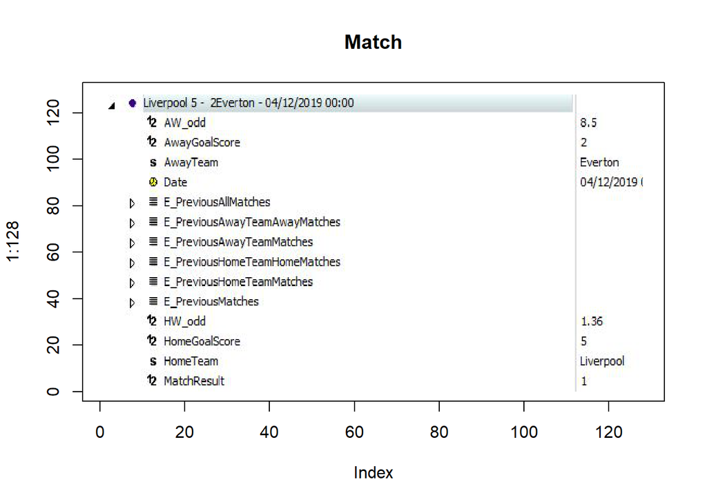

```r
library("jpeg")

#It was possible to use odds in the predictions. When I used odd values, most of learning methods used odd features. I wanted go on with my own features which are calculated based on the past data. For this reason I removed odd data.

#By using object oriented program I established some relations for each match. I am going to explain the relations over the match of Liverpool-Everton played in 04.12.2019 and resulted 5-2 home win.


#Macth data shows data of the match.Following data is created based on the match played in 04.12.2019
#HW_odd =>> Normalized Home Win Probability of match based on odds
#Tie_odd    =>> Normalized Tie Probability of match based on odds
#AW_odd =>> Normalized Away Win Probability of match based on odds
#over_odd   =>> Normalized over 2.5  Probability of match based on odds
#under_odd  =>> Normalized under 2.5  Probability of match based on odds
#Result is 1 if home wins 2 if away wins 0 otherwise
#over if total goal in match is more than 2.5
Match_image<-readJPEG("C:/Users/emreg/Desktop/582/Match.jpg", native = F)
plot(1:128, type='n',main="Match")
rasterImage(Match_image,0,0,128,128,angle = 0,interpolate = F)
```

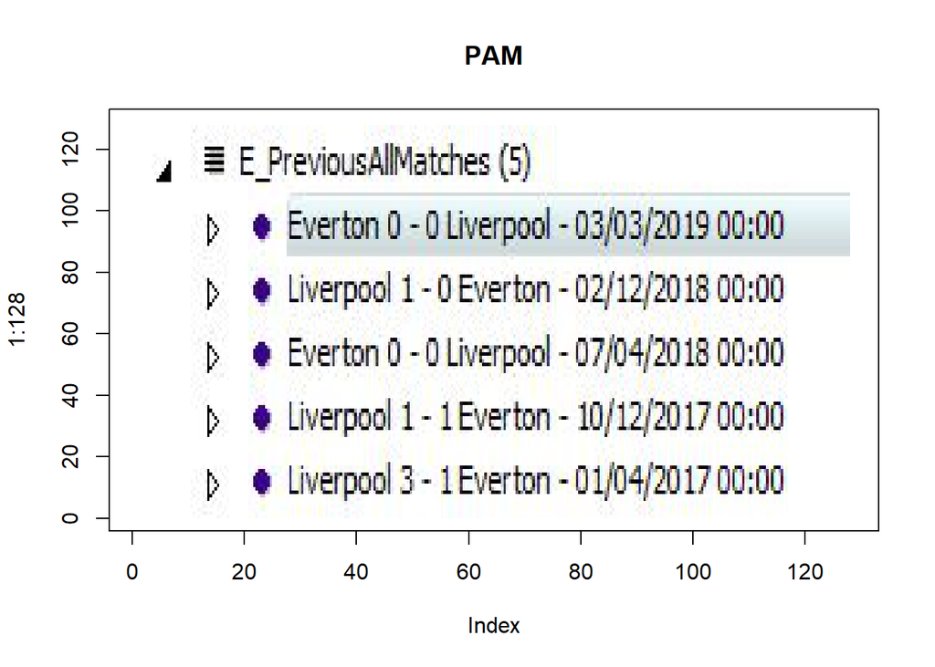

```r
#Previous All  Matches: They are last 5 matches of Liverpool and Everton regardless the stadium
#PAM_G is average total goal of 5 matches.
PAM_image<-readJPEG("C:/Users/emreg/Desktop/582/PAM.jpg", native = F)
plot(1:128, type='n',main="PAM")
rasterImage(PAM_image,0,0,128,128,angle = 0,interpolate = F)
```

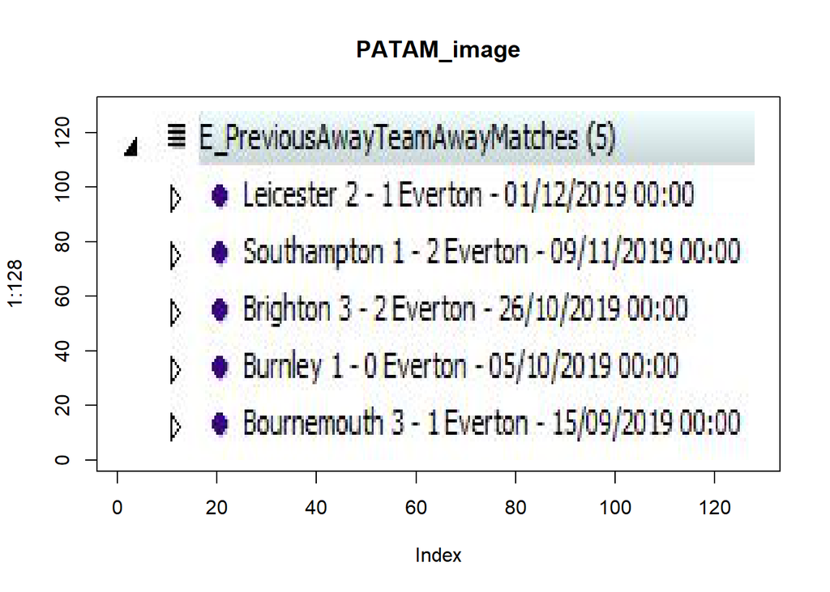

```r
#Previous Away Team Away Matches: They are last 5 matches of Everton when Everton is away team
#PATAM_G is average total goal of 5 matches.
#PATAM_AG is average goals of Everton when Everton is away
PATAM_image<-readJPEG("C:/Users/emreg/Desktop/582/PATAM.jpg", native = F)
plot(1:128, type='n',main="PATAM_image")
rasterImage(PATAM_image,0,0,128,128,angle = 0,interpolate = F)
```

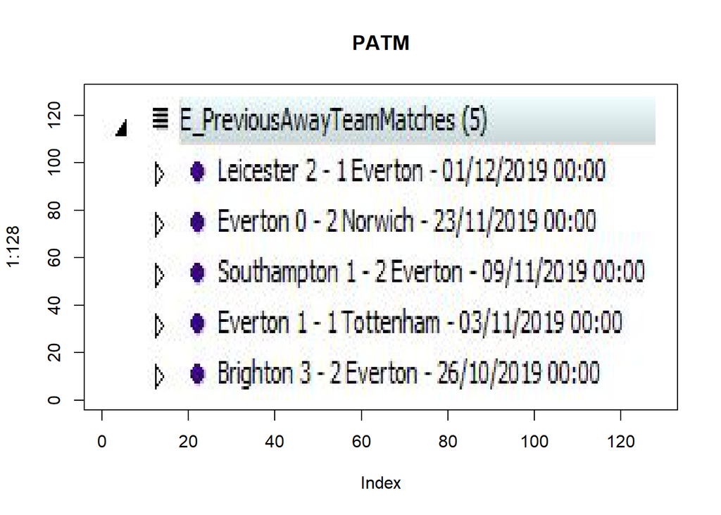

```r
#Previous Away Team  Matches: Last 5 matches of Everton regardless the stadium
#PATM_G is average total goal of 5 matches.
PATM_image<-readJPEG("C:/Users/emreg/Desktop/582/PATM.jpg", native = F)
plot(1:128, type='n',main="PATM")
rasterImage(PATM_image,0,0,128,128,angle = 0,interpolate = F)
```

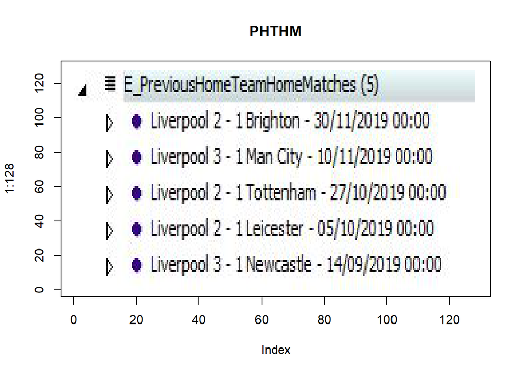

```r
#Previous Home Team Home Matches: Last 5 matches of Liverpool when Liverpool is home team
#PHTHM_G is average total goal of 5 matches.
#PHTHM_AG is average goals of Lİverpool when Liverpool is home
PHTHM_image<-readJPEG("C:/Users/emreg/Desktop/582/PHTHM.jpg", native = F)
plot(1:128, type='n',main="PHTHM")
rasterImage(PHTHM_image,0,0,128,128,angle = 0,interpolate = F)
```

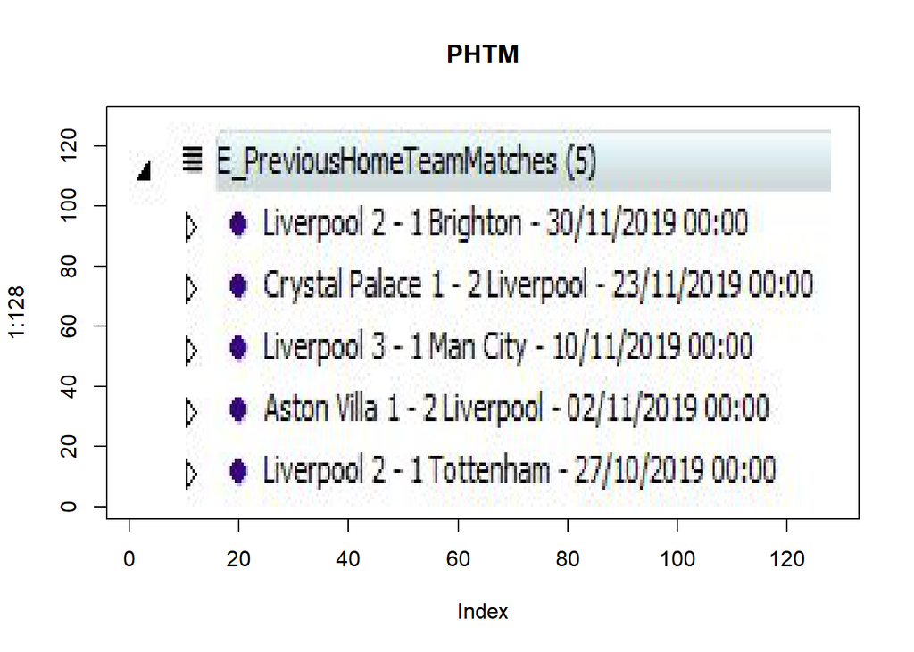

```r
#Previous Home Team Matches: Last 5 match of Liverpool regardless the staidium
#PHTM_G is average total goal of 5 matches.
PHTM_image<-readJPEG("C:/Users/emreg/Desktop/582/PHTM.jpg", native = F)
plot(1:128, type='n',main="PHTM")
rasterImage(PHTM_image,0,0,128,128,angle = 0,interpolate = F)
```

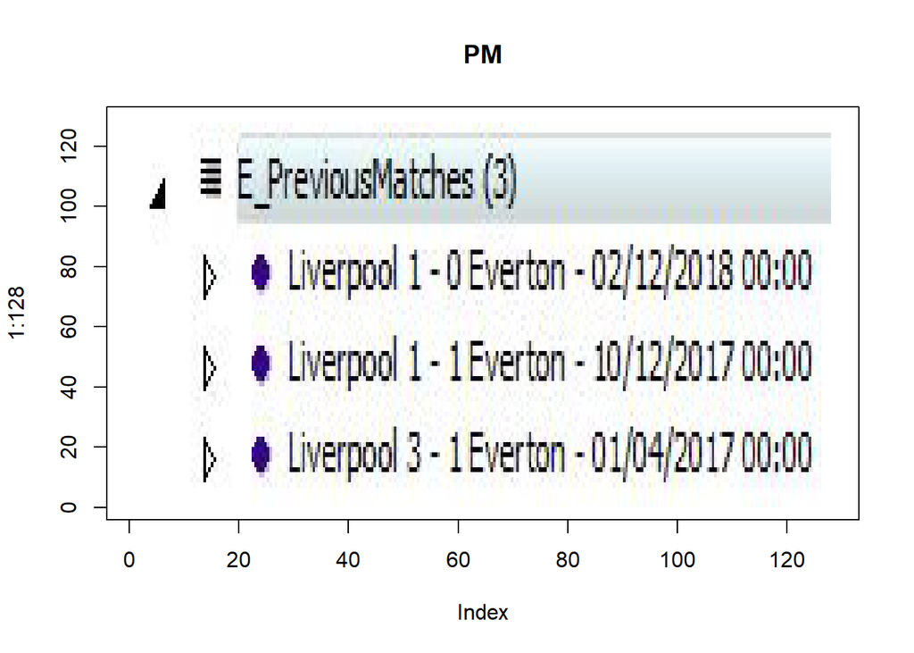

```r
#Previos Matches: Last 3 match of Lverpool and Everton when Liverpool is hometeam and Everton is awayteam
#PM_G is average total goal of 5 matches.
PM_image<-readJPEG("C:/Users/emreg/Desktop/582/PM.jpg", native = F)
plot(1:128, type='n',main="PM")
rasterImage(PM_image,0,0,128,128,angle = 0,interpolate = F)
```

```r
library(tree)
library(TunePareto)
library(MASS)
library(randomForest)
library(data.table)
library(rpart)
library(caret)
library(data.table)
library(dplyr)
library(e1071)
library(gbm)
library(rpart)
library(randomForest)
library(glmnet)
library(rattle)
set.seed(1)
nofReplications=1
nFolds=10

training_raw <- MatchData[MatchData$Date < '2019-01-01',]
test_raw <- MatchData[MatchData$Date >= '2019-01-01',]
training_raw_num <- MacthData_Numeric[MatchData$Date < '2019-01-01',]
test_raw_num <- MacthData_Numeric[MatchData$Date >= '2019-01-01',]


MatchData_Cleaned <- MatchData[,c(7,18:25)]
MatchData_Cleaned_Test <- test_raw[,c(7,18:25)]
MatchData_Cleaned_Training <- training_raw[,c(7,18:25)]

MatchData_Num <- MacthData_Numeric[,c(7:10,18:25)]
MatchData_Num_Test <- test_raw_num[,c(7:10,18:25)]
MatchData_Num_Training <- training_raw_num[,c(7:10,18:25)]
```

I didn’t follow the task order in homework. In the first part I tried to predict over/under classification. In the second part I tried to estimate Total Score.

For each method, first I tried to optimize the paramaters by using 10-fold cross validation. After finding parameters I calculated first training accuracy and then test accuracy. My training data consist of the matches between 2004-2018, test data includes matches after 01/01/2019. There are 5560 matches in total where 328 of them are test data.

————-FIRST PART—————————–

Penalized Regression Approaches (PRA):

```r
set.seed(1)
Lasso = glmnet(as.matrix(MatchData_Cleaned[,-1]),MatchData_Cleaned$over_under,family="binomial", alpha = 1,type.measure = "class",nFolds=10)

lambda_vector= cbind(0.0005,0.0006,0,0007,0.0008,0.0009,0.001,0.002,0.003,0.004,0.005,0.006,01,0.02,0.03,0.04,0.05,0.1,0.2,0.3,0.4,0.5)

lasso_accuracy_vector <- rep(0,22)
accuracy=0
for (i in 1:22){
Lasso_final = glmnet(as.matrix(MatchData_Cleaned[,-1]),MatchData_Cleaned$over_under,family="binomial", alpha = 1,type.measure = "class",nFolds=10,lambda=lambda_vector[,i])
pred.Lasso=predict(Lasso_final, as.matrix(MatchData_Cleaned_Test[,-1]), type = "class")
 accuracy = accuracy + sum(pred.Lasso==MatchData_Cleaned_Test$over_under)/length(pred.Lasso)

 lasso_accuracy_vector[i] = accuracy
 accuracy=0
}

#Test accuracy with cross validation
max(lasso_accuracy_vector)
```

```
## [1] 0.5457317
```

```r
#model with optimized parameter
Lasso_final = glmnet(as.matrix(MatchData_Cleaned_Training[,-1]),MatchData_Cleaned_Training$over_under,family="binomial", alpha = 1,type.measure = "class",nFolds=10,lambda=0.0007)

#Training accuracy
Training_pred.Lasso=predict(Lasso_final, as.matrix(MatchData_Cleaned_Training[,-1]), type = "class")
Training_pred.Lasso=predict(Lasso_final, as.matrix(MatchData_Cleaned_Training[,-1]), type = "class")
sum(Training_pred.Lasso==MatchData_Cleaned_Training$over_under)/length(MatchData_Cleaned_Training$over_under)
```

```
## [1] 0.5389908
```

```r
#Test Accuracy with trained model w/o cross validation
pred.Lasso=predict(Lasso_final, as.matrix(MatchData_Cleaned_Test[,-1]), type = "class")
table(pred.Lasso,MatchData_Cleaned_Test$over_under)
```

```
##
## pred.Lasso over under
##      over   132   110
##      under   44    42
```

```r
sum(pred.Lasso==MatchData_Cleaned_Test$over_under)/length(MatchData_Cleaned_Test$over_under)
```

```
## [1] 0.5304878
```

We see similar accuracy values. Cross validation accuracy is around 55% which is the highest.

————–Decision Tree——————–

```r
library(rpart)

set.seed(1)
cp_vector<-cbind(0.0005,0.001,0.005,0.01)
split_vector <- cbind(35,45,60)
accuracy_vector <- rep(0,12)

accuracy=0
for (k in 1:4){
  for (j in 1:3){
    for (i in 1:10){
      a=556*(i-1)+1
      b=556*i
      MatchData_Cleaned_test <- MatchData_Cleaned[a:b,]
      MatchData_Cleaned_training <- MatchData_Cleaned[-c(a:b),]
      dt1<-rpart(over_under~.,data=MatchData_Cleaned_training,cp=cp_vector[,k],minsplit=split_vector[,j])
      tree.pred=predict(dt1,MatchData_Cleaned_test,type="class")
      accuracy = accuracy + sum(tree.pred==MatchData_Cleaned_test$over_under)/length(tree.pred)
                    }
    accuracy = accuracy/10
    accuracy_vector[(k-1)*3+j]=accuracy
    accuracy=0
                 }
               }

#Cross validation test accuracy
max(accuracy_vector)
```

```
## [1] 0.5260791
```

[figure not shown]

```r
#Based on the values that I obtained with cross validation highest value corresponds 0.001 and minsplit=60. However these values results overfitting. Training accuracy was 70% but test accuracy was 49%. Therefore I used second highest accuracy which is 0.005 and 45
#simplified but very close
dt<-rpart(over_under~.,data=MatchData_Cleaned_Training,cp=0.005,minsplit=45)
fancyRpartPlot(dt)
```

```r
#Training accuracy
tree.pred=predict(dt,MatchData_Cleaned_Training,type="class")
table(tree.pred,MatchData_Cleaned_Training$over_under)
```

```
##
## tree.pred over under
##     over  1287   916
##     under 1365  1664
```

```r
sum(tree.pred==MatchData_Cleaned_Training$over_under)/length(MatchData_Cleaned_Training$over_under)
```

```
## [1] 0.5640291
```

```r
#Test accuracy
tree.pred=predict(dt,MatchData_Cleaned_Test,type="class")
table(tree.pred,MatchData_Cleaned_Test$over_under)
```

```
##
## tree.pred over under
##     over   108    87
##     under   68    65
```

```r
sum(tree.pred==MatchData_Cleaned_Test$over_under)/length(MatchData_Cleaned_Test$over_under)
```

```
## [1] 0.527439
```

———-Random Forest————–

```r
set.seed(1)
rf_accuracy_vector <- rep(0,6)

accuracy=0

  for (j in 1:6){
    for (i in 1:10){
      a=556*(i-1)+1
      b=556*i
      MatchData_test <- MatchData_Cleaned[a:b,]
      MatchData_training <- MatchData_Cleaned[-c(a:b),]
      rf.over_under=randomForest(over_under~.,MatchData_training,mtry=j,importance=TRUE,recursive=FALSE,ntree=500,nodesize=5)
      rf.pred=predict(rf.over_under,MatchData_test,type="class")
      accuracy = accuracy + sum(rf.pred==MatchData_test$over_under)/length(rf.pred)
                    }
    accuracy = accuracy/10
    rf_accuracy_vector[j]=accuracy
    accuracy=0
                 }
#test accuracy with cross validation
max(rf_accuracy_vector)
```

```
## [1] 0.5318345
```

```r
#model with optimized parameters
rf.over_under=randomForest(over_under~.,MatchData_Cleaned_Training,mtry=3,importance=TRUE,recursive=FALSE,ntree=500,nodesize=5)

#training accuracy
rf.pred=predict(rf.over_under,MatchData_Cleaned_Training,type="class")
sum(rf.pred==MatchData_Cleaned_Training$over_under)/length(MatchData_Cleaned_Training$over_under)
```

```
## [1] 0.9998089
```

```r
#test accuracy
rf.pred=predict(rf.over_under,MatchData_Cleaned_Test,type="class")
sum(rf.pred==MatchData_Cleaned_Test$over_under)/length(MatchData_Cleaned_Test$over_under)
```

```
## [1] 0.5396341
```

———-Stochastic Gradient Boosting (SGB):———

```r
set.seed(1)
cvresult=data.table()
nofReplications=1
nFolds=10
noftrees=c(100,200,300)
depth=c(3,5,7)
learning_rate=c(0.0005,0.001,0.05)
obsinnode=10

acc=0
boost_accuracy_vector <- rep(0,27)
    for(y in 1:length(noftrees)){
      for(z in 1:length(depth)){
        for(m in 1:length(learning_rate)){
          for (i in 1:nFolds){
                a=556*(i-1)+1
                b=556*i
                MatchData_Num_test <- MatchData_Num[a:b,]
                MatchData_Num_training <- MatchData_Num[-c(a:b),]
                boosting_model=gbm(over_under~., data=MatchData_Num_training,distribution = "bernoulli", n.trees = noftrees[y], interaction.depth = depth[z], n.minobsinnode = obsinnode, shrinkage =learning_rate[m])
          test_predict=as.data.table(predict(boosting_model,MatchData_Num_test,n.trees=noftrees[y],type="response"))
          test_predict[,over_under:=ifelse(V1<0.5,0,1)]
          con_mat<-table(test_predict$over_under,MatchData_Num_test$over_under)
          acc<-acc+sum(diag(con_mat))/sum(con_mat)

          }
          boost_accuracy_vector[m+(z-1)*length(learning_rate) +(y-1)*length(learning_rate)*length(depth)] <- acc/10
          acc=0
        }
      }
    }

#test accuracy with cross validation
max(boost_accuracy_vector)
```

```
## [1] 0.5523381
```

```r
#model with optimized parameters
boosting_model=gbm(over_under~., data=MatchData_Num_Training,distribution = "bernoulli", n.trees = 200, interaction.depth = 7, n.minobsinnode = obsinnode, shrinkage =0.05)

#training accuracy
training_predict=as.data.table(predict(boosting_model,MatchData_Num_Training,n.trees=100,type="response"))
training_predict[,over_under:=ifelse(V1<0.5,0,1)]
sum(training_predict==MatchData_Num_Training$over_under)/length(MatchData_Num_Training$over_under)
```

```
## [1] 0.6355122
```

```r
#test accuracy
test_predict=as.data.table(predict(boosting_model,MatchData_Num_Test,n.trees=100,type="response"))
test_predict[,over_under:=ifelse(V1<0.5,0,1)]
sum(test_predict==MatchData_Num_Test$over_under)/length(MatchData_Num_Test$over_under)
```

```
## [1] 0.5182927
```

FIRST PART CONCLUSION

Penalized Regression Approaches (PRA): PRA_CrossValidation Accuracy= 0.5457317 PRA_TrainingAccuracy = 0.5389908 PRA_Test Accuracy=0.5304878

Cross validation accuracies are bit more than random guessing. Therefore there is an underfitting problem. I need to find better features which can increase the accuracy. ————— Second Part——————————————–

———Data Formating——–

```r
MacthData_Numeric_TG <- cbind(MacthData_Numeric,TotalGoal=MacthData_Numeric$HomeGoal+MacthData_Numeric$AwayGoal)

training_raw_num_TG <- MacthData_Numeric_TG[MatchData$Date < '2019-01-01',]
test_raw_num_TG <- MacthData_Numeric_TG[MatchData$Date >= '2019-01-01',]

MatchData_Cleaned_TG <- MacthData_Numeric_TG[,c(26,18:25)]
MatchData_Cleaned_Test_TG <- test_raw_num_TG[,c(26,18:25)]
MatchData_Cleaned_Training_TG <- training_raw_num_TG[,c(26,18:25)]

summary(MatchData_Cleaned_Training_TG$TotalGoal)
```

```
##    Min. 1st Qu.  Median    Mean 3rd Qu.    Max.
##   0.000   1.000   3.000   2.678   4.000  11.000
```

```r
#sample data
head(MatchData_Cleaned_TG)
```

```
##   TotalGoal PAM_G PATAM_G   PATM_G PHTHM_G PHTM_G     PM_G PHTHM_HG
## 1         7   1.4     3.2 2.547945     3.4    3.2 2.333333      2.4
## 2         2   2.6     3.4 2.656863     3.2    3.6 2.333333      2.6
## 3         3   2.6     4.2 2.638298     1.8    3.0 2.666667      1.2
## 4         2   2.4     2.0 2.708661     3.2    2.4 2.333333      1.6
## 5         3   2.0     3.2 2.789384     2.6    3.8 1.666667      1.6
## 6         3   2.2     1.6 2.828431     4.8    4.4 3.666667      1.0
##   PATAM_AG
## 1      1.2
## 2      0.8
## 3      2.0
## 4      0.6
## 5      1.2
## 6      0.4
```

——————–Penalized Regression Approaches (PRA): ——————

```r
set.seed(1)
Lasso = glmnet(as.matrix(MatchData_Cleaned_TG[,-1]),MatchData_Cleaned_TG$TotalGoal,family="gaussian", alpha = 1,nFolds=10)

lambda_vector= cbind(0.0007,0.001,0.002,0.003,0.004,0.005,0.006,0.01,0.02,0.03,0.04,0.05,0.1,0.2,0.3,0.4,0.5,0.6,0.7,0.8,0.9,0.99)

lasso_accuracy_vector <- rep(0,22)
accuracy=0
for (i in 1:22){
Lasso_final = glmnet(as.matrix(MatchData_Cleaned_TG[,-1]),MatchData_Cleaned_TG$TotalGoal,family="gaussian", alpha = 1,nFolds=10,lambda=lambda_vector[,i])
pred.Lasso=predict(Lasso_final, as.matrix(MatchData_Cleaned_Test_TG[,-1]))
 accuracy = accuracy + sum(abs(pred.Lasso-MatchData_Cleaned_Test_TG$TotalGoal))/length(MatchData_Cleaned_Test_TG$TotalGoal)

 lasso_accuracy_vector[i] = accuracy
 accuracy=0
}
#cross validation mean absolute accuracy
min(lasso_accuracy_vector)
```

```
## [1] 1.237254
```

```r
Lasso_final = glmnet(as.matrix(MatchData_Cleaned_Training_TG[,-1]),MatchData_Cleaned_Training_TG$TotalGoal,family="gaussian", alpha = 1,nFolds=10,lambda=0.5)

#training accuracy
training_pred.Lasso=predict(Lasso_final, as.matrix(MatchData_Cleaned_Training_TG[,-1]))
(sum(abs(training_pred.Lasso-MatchData_Cleaned_Training_TG$TotalGoal)) / length(MatchData_Cleaned_Training_TG$TotalGoal))
```

```
## [1] 1.344261
```

```r
#test accuracy
pred.Lasso=predict(Lasso_final, as.matrix(MatchData_Cleaned_Test_TG[,-1]))
(sum(abs(pred.Lasso-MatchData_Cleaned_Test_TG$TotalGoal)) / length(MatchData_Cleaned_Test_TG$TotalGoal))
```

```
## [1] 1.246112
```

———–Decision Trees (DT):—————–

```r
set.seed(1)
cp_vector<-cbind(0.0005,0.001,0.002,0.005)
split_vector <- cbind(35,45,60)
accuracy_vector <- rep(0,12)

accuracy=0
for (k in 1:4){
  for (j in 1:3){
    for (i in 1:10){
      a=556*(i-1)+1
      b=556*i
      MatchData_Cleaned_test <- MatchData_Cleaned_TG[a:b,]
      MatchData_Cleaned_training <- MatchData_Cleaned_TG[-c(a:b),]
      dt1<-rpart(TotalGoal~.,data=MatchData_Cleaned_training,cp=cp_vector[,k],minsplit=split_vector[,j])
      tree.pred=predict(dt1,MatchData_Cleaned_test)
      accuracy = accuracy + sum(abs(tree.pred-MatchData_Cleaned_test$TotalGoal))/length(MatchData_Cleaned_test$TotalGoal)
                    }
    accuracy = accuracy/10
    accuracy_vector[(k-1)*3+j]=accuracy
    accuracy=0
                 }
               }

min(accuracy_vector)
```

```
## [1] 1.335695
```

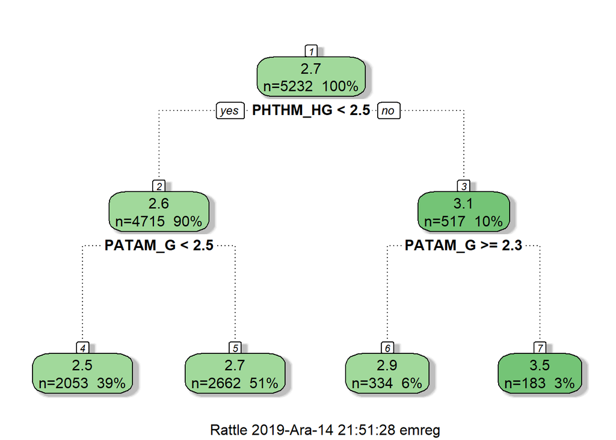

```r
#best accuracy value was 0.001 and 35 but it was overfitting
#simplified but very close
dt<-rpart(TotalGoal~.,data=MatchData_Cleaned_Training_TG,cp=0.002,minsplit=35)
fancyRpartPlot(dt)
```

```r
#training accuracy
training_tree.pred=predict(dt,MatchData_Cleaned_Training_TG)
sum(abs(training_tree.pred-MatchData_Cleaned_Training_TG$TotalGoal))/length(MatchData_Cleaned_Training_TG$TotalGoal)
```

```
## [1] 1.336309
```

```r
#test accuracy
tree.pred=predict(dt,MatchData_Cleaned_Test_TG)
sum(abs(tree.pred-MatchData_Cleaned_Test_TG$TotalGoal))/length(MatchData_Cleaned_Test_TG$TotalGoal)
```

```
## [1] 1.24291
```

————-Random Forests (RF)——————-

```r
set.seed(1)
rf_accuracy_vector <- rep(0,6)

accuracy=0

  for (j in 1:6){
    for (i in 1:10){
      a=556*(i-1)+1
      b=556*i
      MatchData_test <- MatchData_Cleaned_TG[a:b,]
      MatchData_training <- MatchData_Cleaned_TG[-c(a:b),]
      TotalGoal=randomForest(TotalGoal~.,MatchData_training,mtry=j,importance=TRUE,recursive=FALSE,ntree=500,nodesize=5)
      rf.pred=predict(TotalGoal,MatchData_test)
      accuracy = accuracy + sum(abs(rf.pred-MatchData_test$TotalGoal))/length(MatchData_test$TotalGoal)
                    }
    accuracy = accuracy/10
    rf_accuracy_vector[j]=accuracy
    accuracy=0
                 }
#cross validation accuracy
min(rf_accuracy_vector)
```

```
## [1] 1.330356
```

```r
#optimized paramters
rf.TG=randomForest(TotalGoal~.,MatchData_Cleaned_Training_TG,mtry=3,importance=TRUE,recursive=FALSE,ntree=500,nodesize=5)

#training accuracy
tr_rf.pred=predict(rf.TG,MatchData_Cleaned_Training_TG)
sum(abs(tr_rf.pred-MatchData_Cleaned_Training_TG$TotalGoal))/length(MatchData_Cleaned_Training_TG$TotalGoal)
```

```
## [1] 0.6106154
```

```r
#test accuracy
rf.pred=predict(rf.TG,MatchData_Cleaned_Test_TG)
sum(abs(rf.pred-MatchData_Cleaned_Test_TG$TotalGoal))/length(MatchData_Cleaned_Test_TG$TotalGoal)
```

```
## [1] 1.250614
```

———-Stochastic Gradient Boosting (SGB):———

```r
set.seed(1)
cvresult=data.table()
nofReplications=1
nFolds=10
noftrees=c(100,200,300)
depth=c(3,5,7)
learning_rate=c(0.0005,0.001,0.05)
obsinnode=10

accuracy=0
boost_accuracy_vector <- rep(0,27)
    for(y in 1:length(noftrees)){
      for(z in 1:length(depth)){
        for(m in 1:length(learning_rate)){
          for (i in 1:nFolds){
                a=556*(i-1)+1
                b=556*i
                MatchData_Num_test <- MatchData_Cleaned_TG[a:b,]
                MatchData_Num_training <- MatchData_Cleaned_TG[-c(a:b),]
                boosting_model=gbm(TotalGoal~., data=MatchData_Num_training,distribution = "gaussian", n.trees = noftrees[y], interaction.depth = depth[z], n.minobsinnode = obsinnode, shrinkage =learning_rate[m])
          test_predict=as.data.table(predict(boosting_model,MatchData_Num_test,n.trees=noftrees[y],type="response"))
          accuracy = accuracy + sum(abs(test_predict-MatchData_Num_test$TotalGoal))/length(MatchData_Num_test$TotalGoal)



          }
          boost_accuracy_vector[m+(z-1)*length(learning_rate) +(y-1)*length(learning_rate)*length(depth)] <- accuracy/10
          accuracy=0
        }
      }
    }
#cross validation accuracy
min(boost_accuracy_vector)
```

```
## [1] 1.326294
```

```r
#optimized paramters
boosting_model=gbm(TotalGoal~., data=MatchData_Cleaned_Training_TG,distribution = "gaussian", n.trees = 200, interaction.depth = 7, n.minobsinnode = obsinnode, shrinkage =0.001)

#training accuracy
training_predict=as.data.table(predict(boosting_model,MatchData_Cleaned_Training_TG,n.trees=100,type="response"))
sum(abs(training_predict-MatchData_Cleaned_Training_TG$TotalGoal))/length(MatchData_Cleaned_Training_TG$TotalGoal)
```

```
## [1] 1.34185
```

```r
#test accuracy
test_predict=as.data.table(predict(boosting_model,MatchData_Cleaned_Test_TG,n.trees=100,type="response"))
sum(abs(test_predict-MatchData_Cleaned_Test_TG$TotalGoal))/length(MatchData_Cleaned_Test_TG$TotalGoal)
```

```
## [1] 1.244371
```

SECOND PART CONCLUSION

Decision Trees (DT): DT_CrossValidation MAE= 1.335695 DT_Training MAE = 1.336309 DT_Test MAE= 1.24291

When we compare Test MAE and Croos_validation MAE results, we see that cross validation MAE is not lower than Test MAE except PRA. Normally we expect the opposite. In Random Forest, we see that there are significant differences between training and test MAEs. This implies that there is an overfitting problem. When we compare the results we can select Penalized Regression since MAE is relatively low and there is no overfitting.

In total average goal is 2.68, Therefore 1.24 MAE is high error rate. Therefore there is an underfitting problem. I need to find better features which can increase the accuracy